# Linear Model Selection and Regularization - Guided

# Definitions

## Best Subset Selection

To perform best subset selection, we fit a separate least squares regression for each possible combination of the `p` predictors. That is, we fit all `p` models selection that contain exactly one predictor, all $(^{p}_{2}) = p(p - 1)/2$ models that contain exactly two predictors, and so forth. We then look at all of the resulting models, with the goal of identifying the one that is best.

We can define *best* by utilizing cross-validated prediction error, $C_p$, $BIC$, or adjusted $R^2$ in order to select among the models.

## Forward Stepwise Selection

Forward stepwise selection is a computationally efficient alternative to best subset selection. While the best subset selection procedure considers all $2^p$ possible models containing subsets of the `p` predictors, forward stepwise considers a much smaller set of models. Forward stepwise selection begins with a model containing no predictors, and then adds predictors to the model, one-at-a-time, until all of the predictors are in the model. In particular, at each step the variable that gives the greatest additional improvement to the fit is added to the model.

Note that forward stepwise selection **is not guaranteed** to yield the *best* model containing a subset of the `p` predictors. (See page 209 for a great example of this…)

Forward stepwise can be used even when $n < p$, and so is the only viable subset method when `p` is very large.

## Backward Stepwise Selection

Like forward stepwise selection, backward stepwise selection provides an efficient alternative to best subset selection. However, unlike forward stepwise selection, it begins with the full least squares model containing all `p` predictors, and then iteratively removes the least useful predictor, one-at-a-time.

Like forward stepwise selection, backward stepwise selection **is not guaranteed** to yield the *best* model containing a subset of the `p` predictors.

Backward selection requires that the number of samples `n` is larger than the number of variables `p` (so that the full model can be fit). In contrast, forward stepwise can be used even when $n < p$, and so is the only viable subset method when `p` is very large.

## Cp

For a fitted least squares model containing `d` predictors, the $C_p$ estimate of test MSE is computed using the equation

$C_p = \frac{1}{n}(RSS + 2d\hat{\sigma}^2)$

The $C_p$ statistic tends to take on a small value for models with a low test error, so when determining which of a set of models is best, we choose the model with the lowest $C_p$ value.

## Bayesian Information Criterion (BIC)

BIC is derived from a Bayesian point of view, but ends up looking similar to $C_p$. For the least squares model with `d` predictors, the BIC is, up to irrelevant constants, given by

$BIC = \frac{1}{n\sigma^2}(RSS + log(n)d\sigma^2)$

Like $C_p$, the BIC will tend to take on a small value for a model with a low test error, and so generally we select the model that has the lowest BIC value.

## Adjusted R-squared

The adjusted R-squared compares the explanatory power of regression models that contain different numbers of predictors.

Suppose you compare a five-predictor model with a higher R-squared to a one-predictor model. Does the five predictor model have a higher R-squared because it’s better? Or is the R-squared higher because it has more predictors? Comparing the adjusted R-squared values for the models gives us a way to decide between the two while mitigating the increase in the R-squared statistic that results from simply adding predictors whether significant or not.

The adjusted R-squared is a modified version of R-squared that has been adjusted for the number of predictors in the model. The adjusted R-squared increases only if the new term improves the model more than would be expected by chance. It decreases when a predictor improves the model by less than expected by chance. The adjusted R-squared can be negative, but it’s usually not. It is always lower than the R-squared.

## Ridge Regression

Ridge regression is a model regularization method that utilizes shrinkage (i.e. ridge regression shrinks the coefficient estimates towards zero).

- Ridge Regression controls shrinkage via a tuning parameter, $\lambda$. When $\lambda = 0$, the penalty term has no effect, and ridge regression will produce the least squares estimates. However, as $\lambda \rightarrow \infty$, the impact of the shrinkage penalty grows, and the ridge regression coefficient estimates will approach zero.
- Ridge Regression, unlike the Lasso below, will always generate a model involving all predictors. Increasing the value of $\lambda$ will tend to reduce the magnitudes of the coefficients, but will not result in exclusion of any of the variables.
- Ridge Regression is affected by scale, so it is best to apply ridge regression after *standardizing the predictors* so that they are all on the same scale.
- Ridge regression’s advantage over least squares is rooted in the bias-variance trade-off. As $\lambda$ increases, the flexibility of the ridge regression fit decreases, leading to decreased variance but increased bias.
- Ridge regression works best in situations where the least squares estimates have high variance.

## The Lasso

As with ridge regression, the lasso shrinks the coefficient estimates towards zero. However, in the case of the lasso, the $l_1$ penalty has the effect of forcing some of the coefficient estimates to be exactly equal to zero when the tuning parameter $\lambda$ is sufficiently large. Hence, much like best subset selection, the lasso performs *variable selection*.

- The lasso yields sparse models-that is, models that involve only a subset of the variables.

## Principal Component Regression (PCR)

In statistics, principal component regression (PCR) is a regression analysis technique that is based on principal component analysis (PCA). Typically, it considers regressing the outcome (also known as the response or the dependent variable) on a set of covariates (also known as predictors, or explanatory variables, or independent variables) based on a standard linear regression model, but uses PCA for estimating the unknown regression coefficients in the model.

In PCR, instead of regressing the dependent variable on the explanatory variables directly, the principal components of the explanatory variables are used as regressors. One typically uses only a subset of all the principal components for regression, thus making PCR some kind of a regularized procedure. Often the principal components with higher variances (the ones based on eigenvectors corresponding to the higher eigenvalues of the sample variance-covariance matrix of the explanatory variables) are selected as regressors. However, for the purpose of predicting the outcome, the principal components with low variances may also be important, in some cases even more important.

One major use of PCR lies in overcoming the multicollinearity problem which arises when two or more of the explanatory variables are close to being collinear. PCR can aptly deal with such situations by excluding some of the low-variance principal components in the regression step. In addition, by usually regressing on only a subset of all the principal components, PCR can result in dimension reduction through substantially lowering the effective number of parameters characterizing the underlying model. This can be particularly useful in settings with high-dimensional covariates. Also, through appropriate selection of the principal components to be used for regression, PCR can lead to efficient prediction of the outcome based on the assumed model.

[Source](https://en.wikipedia.org/wiki/Principal_component_regression)

The PCR involves identifying linear combinations, or directions, that best represent the predictors X1,…,Xp. These directions are identified in an unsupervised way, since the response Y is not used to help determine the principal component directions. That is, the response does not supervise the identification of the principal components. Consequently, PCR suffers from a drawback: there is no guarantee that the directions that best explain the predictors will also be the best directions to use for predicting the response.

## Partial Least Squares (PLS)

Partial least squares (PLS) is a supervised alternative to partial least PCR. Like PCR, PLS is a dimension reduction method, which first identifies squares a new set of features Z1,…,ZM that are linear combinations of the original features, and then fits a linear model via least squares using these M new features. But unlike PCR, PLS identifies these new features in a supervised way-that is, it makes use of the response Y in order to identify new features that not only approximate the old features well, but also that are related to the response. Roughly speaking, the PLS approach attempts to find directions that help explain both the response and the predictors.

# Lab Exercises

## Lab 1: Subset Selection Methods

### Load and examine the data

```r
library(ISLR)
attach(Hitters)
head(Hitters)
```

|  | AtBat | Hits | HmRun | Runs | RBI | Walks | Years | CAtBat | CHits | CHmRun | CRuns | CRBI | CWalks | League | Division | PutOuts | Assists | Errors | Salary | NewLeague |
| --- | --- | --- | --- | --- | --- | --- | --- | --- | --- | --- | --- | --- | --- | --- | --- | --- | --- | --- | --- | --- |
| -Andy Allanson | 293 | 66 | 1 | 30 | 29 | 14 | 1 | 293 | 66 | 1 | 30 | 29 | 14 | A | E | 446 | 33 | 20 | NA | A |
| -Alan Ashby | 315 | 81 | 7 | 24 | 38 | 39 | 14 | 3449 | 835 | 69 | 321 | 414 | 375 | N | W | 632 | 43 | 10 | 475.0 | N |
| -Alvin Davis | 479 | 130 | 18 | 66 | 72 | 76 | 3 | 1624 | 457 | 63 | 224 | 266 | 263 | A | W | 880 | 82 | 14 | 480.0 | A |
| -Andre Dawson | 496 | 141 | 20 | 65 | 78 | 37 | 11 | 5628 | 1575 | 225 | 828 | 838 | 354 | N | E | 200 | 11 | 3 | 500.0 | N |
| -Andres Galarraga | 321 | 87 | 10 | 39 | 42 | 30 | 2 | 396 | 101 | 12 | 48 | 46 | 33 | N | E | 805 | 40 | 4 | 91.5 | N |
| -Alfredo Griffin | 594 | 169 | 4 | 74 | 51 | 35 | 11 | 4408 | 1133 | 19 | 501 | 336 | 194 | A | W | 282 | 421 | 25 | 750.0 | A |

We do have some ‘NA’ values in the data, so let’s identify which columns contain missing values:

```r
# The '2' below indicates we want to test over columns
apply(Hitters, 2, function(x) any(is.na(x)))
```

```
##     AtBat      Hits     HmRun      Runs       RBI     Walks     Years
##     FALSE     FALSE     FALSE     FALSE     FALSE     FALSE     FALSE
##    CAtBat     CHits    CHmRun     CRuns      CRBI    CWalks    League
##     FALSE     FALSE     FALSE     FALSE     FALSE     FALSE     FALSE
##  Division   PutOuts   Assists    Errors    Salary NewLeague
##     FALSE     FALSE     FALSE     FALSE      TRUE     FALSE
```

How many rows have missing *Salary* data?

```r
{
print(sum(is.na(Hitters$Salary)))
print(paste(round(sum(is.na(Hitters$Salary)) / dim(Hitters)[1] * 100), '%', sep = ''))
}
```

```
## [1] 59
## [1] "18%"
```

So roughly 18% of the data has missing values. Let’s go ahead and omit them:

```r
{
data = na.omit(Hitters)
dim(data)
}
```

```
## [1] 263  20
```

### Best Subset Selection

Next we’ll use best subset selection to predict a baseball player’s salary based on one or more variables. The regsubsets() function (part of the leaps library) performs best subset selection by identifying the best model that contains a given number of predictors, where best is quantified using RSS. Later on we’ll examine the ‘best’ model utilizing other metrics besides RSS.

```r
library(leaps)
fit = regsubsets(Salary ~ ., data = data)
summary(fit)$outmat
```

```
##          AtBat Hits HmRun Runs RBI Walks Years CAtBat CHits CHmRun CRuns
## 1  ( 1 ) " "   " "  " "   " "  " " " "   " "   " "    " "   " "    " "
## 2  ( 1 ) " "   "*"  " "   " "  " " " "   " "   " "    " "   " "    " "
## 3  ( 1 ) " "   "*"  " "   " "  " " " "   " "   " "    " "   " "    " "
## 4  ( 1 ) " "   "*"  " "   " "  " " " "   " "   " "    " "   " "    " "
## 5  ( 1 ) "*"   "*"  " "   " "  " " " "   " "   " "    " "   " "    " "
## 6  ( 1 ) "*"   "*"  " "   " "  " " "*"   " "   " "    " "   " "    " "
## 7  ( 1 ) " "   "*"  " "   " "  " " "*"   " "   "*"    "*"   "*"    " "
## 8  ( 1 ) "*"   "*"  " "   " "  " " "*"   " "   " "    " "   "*"    "*"
##          CRBI CWalks LeagueN DivisionW PutOuts Assists Errors NewLeagueN
## 1  ( 1 ) "*"  " "    " "     " "       " "     " "     " "    " "
## 2  ( 1 ) "*"  " "    " "     " "       " "     " "     " "    " "
## 3  ( 1 ) "*"  " "    " "     " "       "*"     " "     " "    " "
## 4  ( 1 ) "*"  " "    " "     "*"       "*"     " "     " "    " "
## 5  ( 1 ) "*"  " "    " "     "*"       "*"     " "     " "    " "
## 6  ( 1 ) "*"  " "    " "     "*"       "*"     " "     " "    " "
## 7  ( 1 ) " "  " "    " "     "*"       "*"     " "     " "    " "
## 8  ( 1 ) " "  "*"    " "     "*"       "*"     " "     " "    " "
```

So the ‘best’ (i.e. smallest RSS) model w/ two variables is ‘Hits|CRBI’, and the ‘best’ model with three variables is ‘Hits|CRBI|PutOuts’.

Note the ‘regsubsets’ by default only calculates up to the best eight-variable model. Before we proceed let’s include the full complement of variables:

```r
fit = regsubsets(Salary ~ ., data = data, nvmax = 19)
sfit = summary(fit)
```

The problem with using $RSS$ and/or $R^2$ to select the best model was highlighted in the text: The $RSS$ of these $p + 1$ models decreases monotonically, and the $R^2$ increases monotonically, as the number of features included in the models increases. Thus we need to evaluate and select the best model utilizing other metrics that don’t suffer from these flaws, and we can use the $C_p$, $BIC$, or adjusted $R^2$ statistics for this purpose.

We can plot the aforementioned metrics of performance (i.e. $RSS$, $C_p$, $BIC$, and adjusted $R^2$) together for comparison:

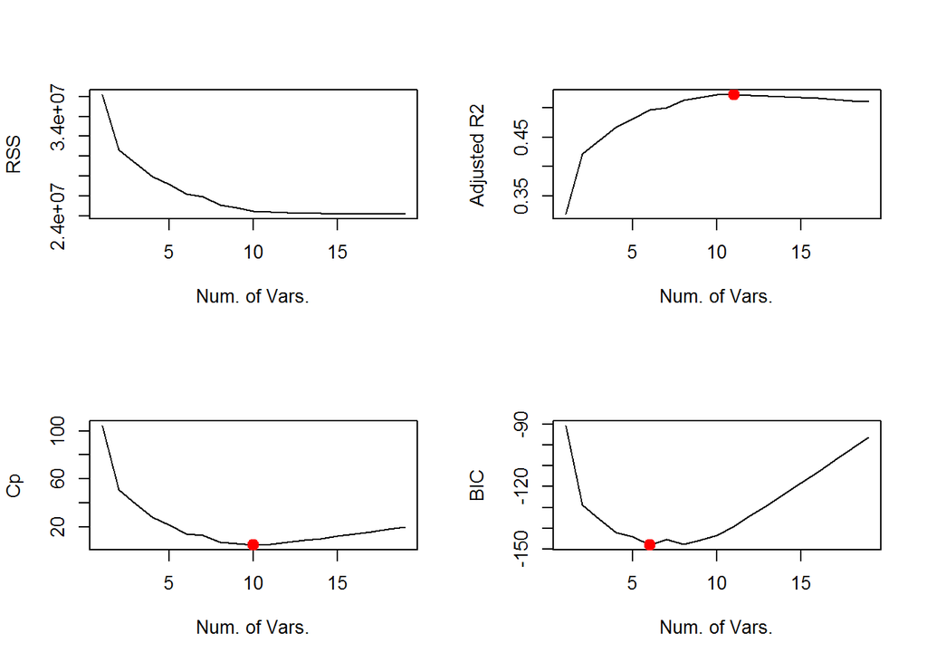

```r
par(mfrow = c(2,2))

{
  # Plot RSS
  plot(sfit$rss, xlab = "Num. of Vars.", ylab = 'RSS', type = 'l')

  # Plot adjusted R2 w/ indicator for the model with the largest adjusted R2 statistic
  plot(sfit$adjr2, xlab = "Num. of Vars.", ylab = 'Adjusted R2', type = 'l')
  points(which.max(sfit$adjr2), sfit$adjr2[which.max(sfit$adjr2)], col = 'red', cex = 2, pch = 20)

  # Plot adjusted Cp w/ indicator for the model with the smallest Cp statistic
  plot(sfit$cp, xlab = "Num. of Vars.", ylab = 'Cp', type = 'l')
  points(which.min(sfit$cp), sfit$cp[which.min(sfit$cp)], col = 'red', cex = 2, pch = 20)

  # Plot adjusted BIC w/ indicator for the model with the smallest BIC statistic
  plot(sfit$bic, xlab = "Num. of Vars.", ylab = 'BIC', type = 'l')
  points(which.min(sfit$bic), sfit$bic[which.min(sfit$bic)], col = 'red', cex = 2, pch = 20)
}
```

Or we can view plots using built in regsubsets functionality, although frankly I don’t care for these:

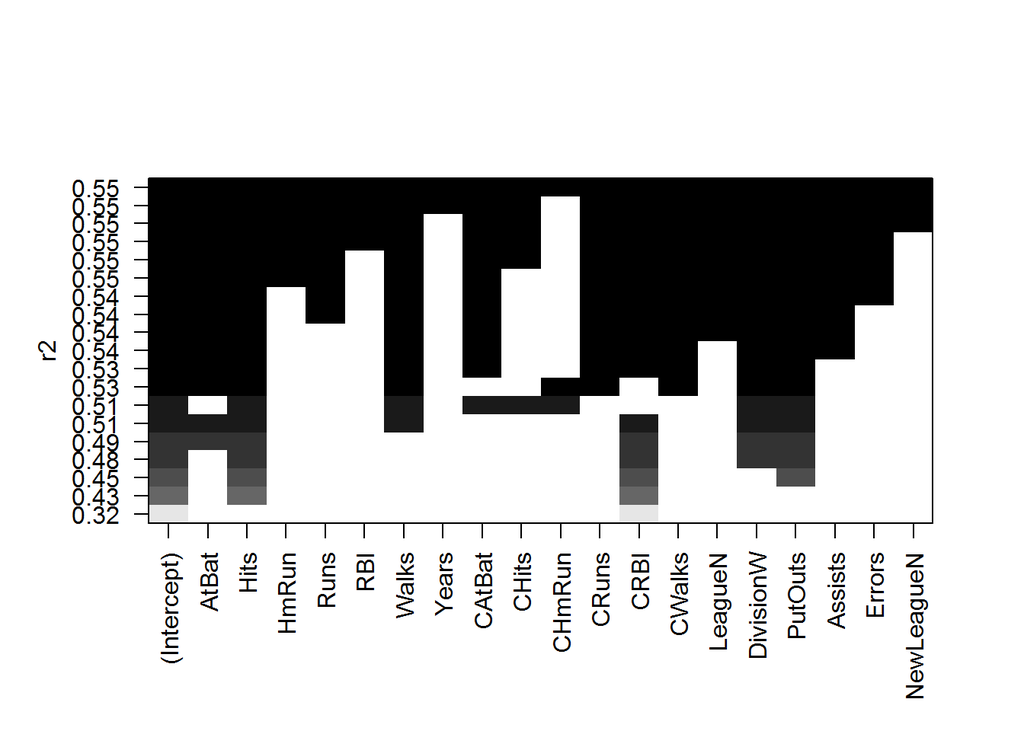

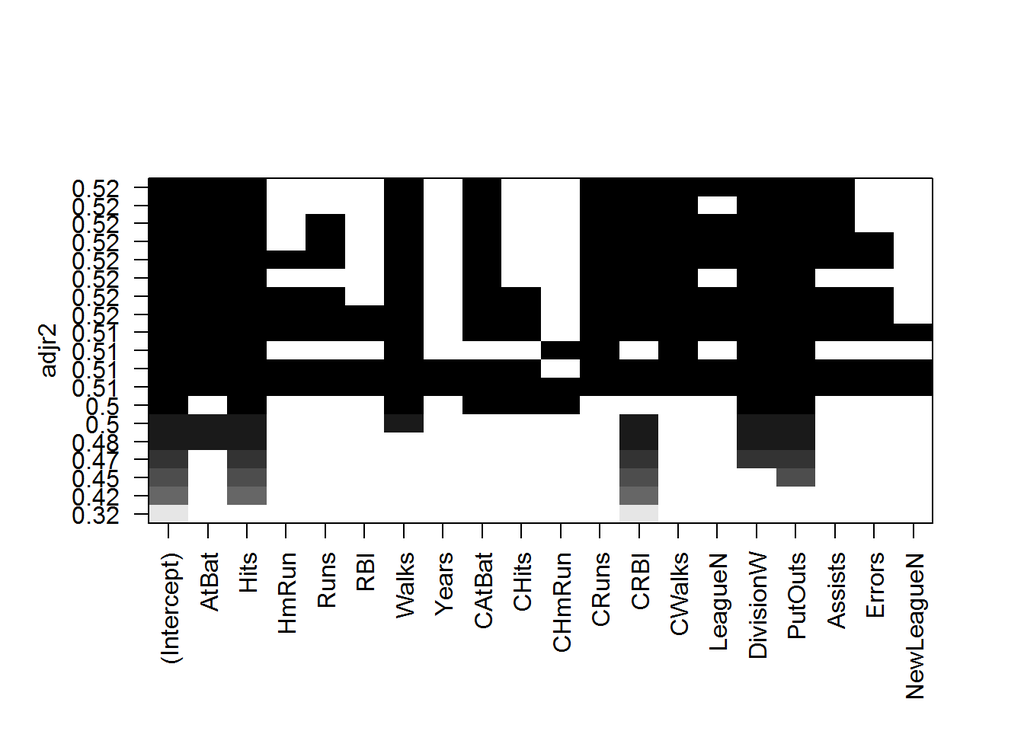

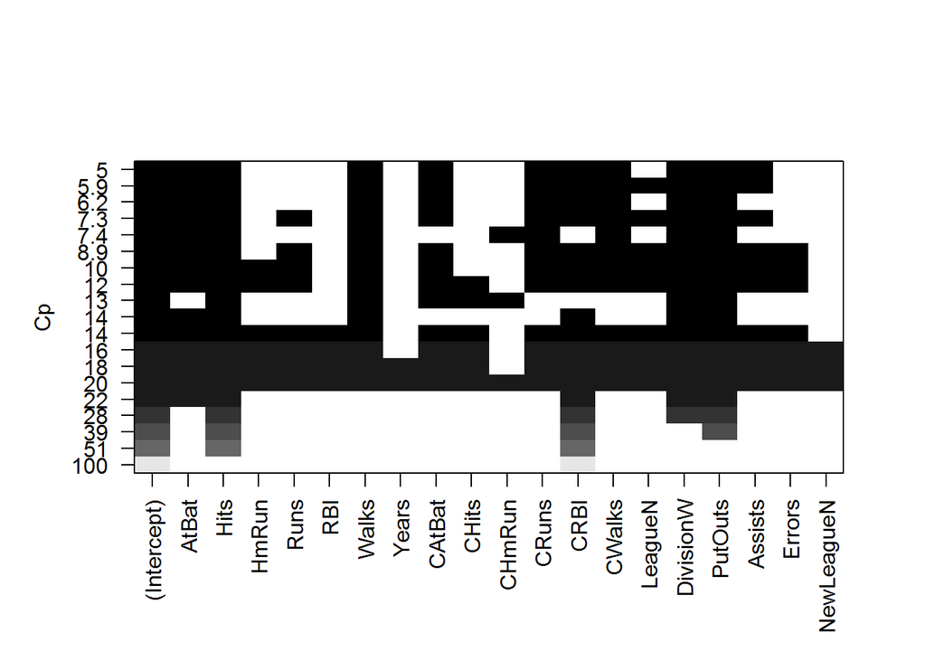

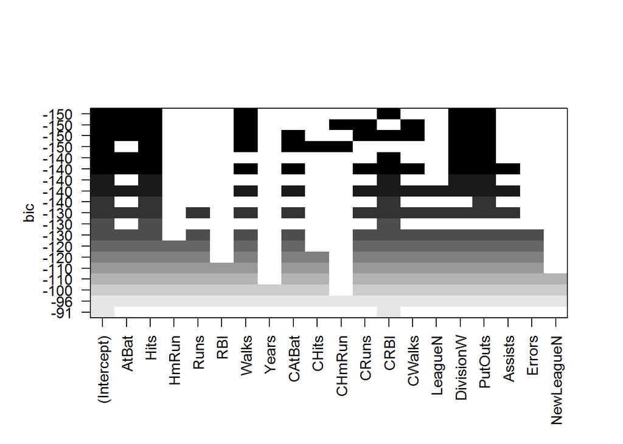

```r
{
plot(fit,scale="r2")
plot(fit,scale="adjr2")
plot(fit,scale="Cp")
plot(fit,scale="bic")
}
```

### Forward and Backward Stepwise Selection

```r
# Forward stepwise selection
fit = regsubsets(Salary ~ ., data = data, method = 'forward')
summary(fit)$outmat
```

```
##          AtBat Hits HmRun Runs RBI Walks Years CAtBat CHits CHmRun CRuns
## 1  ( 1 ) " "   " "  " "   " "  " " " "   " "   " "    " "   " "    " "
## 2  ( 1 ) " "   "*"  " "   " "  " " " "   " "   " "    " "   " "    " "
## 3  ( 1 ) " "   "*"  " "   " "  " " " "   " "   " "    " "   " "    " "
## 4  ( 1 ) " "   "*"  " "   " "  " " " "   " "   " "    " "   " "    " "
## 5  ( 1 ) "*"   "*"  " "   " "  " " " "   " "   " "    " "   " "    " "
## 6  ( 1 ) "*"   "*"  " "   " "  " " "*"   " "   " "    " "   " "    " "
## 7  ( 1 ) "*"   "*"  " "   " "  " " "*"   " "   " "    " "   " "    " "
## 8  ( 1 ) "*"   "*"  " "   " "  " " "*"   " "   " "    " "   " "    "*"
##          CRBI CWalks LeagueN DivisionW PutOuts Assists Errors NewLeagueN
## 1  ( 1 ) "*"  " "    " "     " "       " "     " "     " "    " "
## 2  ( 1 ) "*"  " "    " "     " "       " "     " "     " "    " "
## 3  ( 1 ) "*"  " "    " "     " "       "*"     " "     " "    " "
## 4  ( 1 ) "*"  " "    " "     "*"       "*"     " "     " "    " "
## 5  ( 1 ) "*"  " "    " "     "*"       "*"     " "     " "    " "
## 6  ( 1 ) "*"  " "    " "     "*"       "*"     " "     " "    " "
## 7  ( 1 ) "*"  "*"    " "     "*"       "*"     " "     " "    " "
## 8  ( 1 ) "*"  "*"    " "     "*"       "*"     " "     " "    " "
```

```r
# Backward stepwise selection
fit = regsubsets(Salary ~ ., data = data, method = 'backward')
summary(fit)$outmat
```

```
##          AtBat Hits HmRun Runs RBI Walks Years CAtBat CHits CHmRun CRuns
## 1  ( 1 ) " "   " "  " "   " "  " " " "   " "   " "    " "   " "    "*"
## 2  ( 1 ) " "   "*"  " "   " "  " " " "   " "   " "    " "   " "    "*"
## 3  ( 1 ) " "   "*"  " "   " "  " " " "   " "   " "    " "   " "    "*"
## 4  ( 1 ) "*"   "*"  " "   " "  " " " "   " "   " "    " "   " "    "*"
## 5  ( 1 ) "*"   "*"  " "   " "  " " "*"   " "   " "    " "   " "    "*"
## 6  ( 1 ) "*"   "*"  " "   " "  " " "*"   " "   " "    " "   " "    "*"
## 7  ( 1 ) "*"   "*"  " "   " "  " " "*"   " "   " "    " "   " "    "*"
## 8  ( 1 ) "*"   "*"  " "   " "  " " "*"   " "   " "    " "   " "    "*"
##          CRBI CWalks LeagueN DivisionW PutOuts Assists Errors NewLeagueN
## 1  ( 1 ) " "  " "    " "     " "       " "     " "     " "    " "
## 2  ( 1 ) " "  " "    " "     " "       " "     " "     " "    " "
## 3  ( 1 ) " "  " "    " "     " "       "*"     " "     " "    " "
## 4  ( 1 ) " "  " "    " "     " "       "*"     " "     " "    " "
## 5  ( 1 ) " "  " "    " "     " "       "*"     " "     " "    " "
## 6  ( 1 ) " "  " "    " "     "*"       "*"     " "     " "    " "
## 7  ( 1 ) " "  "*"    " "     "*"       "*"     " "     " "    " "
## 8  ( 1 ) "*"  "*"    " "     "*"       "*"     " "     " "    " "
```

For this data, the best one-variable through six-variable models are each identical for best subset and forward selection. However, the best seven-variable models identified by forward stepwise selection, backward stepwise selection, and best subset selection are different.

### Choosing Among Models Using the Validation Set Approach and Cross-Validation

**Validation Set Approach**

First, create the training and test sets:

```r
set.seed(1)

train = sample(c(T, F), nrow(data), replace = T)
test = (!train)
```

Next, train the best subset model on the training data, and create a matrix out of the test observations:

```r
fit = regsubsets(Salary ~ ., data = data[train, ], nvmax = 19)

# This command makes a matrix out of the values in the Hitters dataframe and adds an (Intercept) term as well as
# converting qualitative variables to dummies
mat = model.matrix(Salary ~ ., data = data[test, ])
```

OK, at this point we have a set of coefficients from the trained model, and a set of values from the held out test set. What we should be able to do is multiply the coefficients of the trained model against the values in the test matrix, obtain a prediction for Salary, and then measure how well the predictions fit the actual values:

```r
# Container for the error rate for each of the 19 models
errs = rep(0, 19)

# Loop through each model
for (i in 1:19) {
  # Obtain coefficients for the ith model
  c = coef(fit, id = i)

  # Obtain values from the test data matrix lining up w/ the columns selected by the model
  v = mat[, names(c)]

  # Use matrix multiplication to multiply the fitted coefficients with the test data values
  p = v %*% c

  # Calculate and record the prediction errors
  errs[i] = mean((data$Salary[test] - p)^2)
}

{
  print(errs)
  print(which.min(errs))
}
```

```
##  [1] 220968.0 169157.1 178518.2 163426.1 168418.1 171270.6 162377.1
##  [8] 157909.3 154055.7 148162.1 151156.4 151742.5 152214.5 157358.7
## [15] 158541.4 158743.3 159972.7 159859.8 160105.6
## [1] 10
```

So the model with 10 predictors has the lowest error rating on the test data set.

```r
coef(fit, 10)
```

```
## (Intercept)       AtBat        Hits       Walks      CAtBat       CHits
## -80.2751499  -1.4683816   7.1625314   3.6430345  -0.1855698   1.1053238
##      CHmRun      CWalks     LeagueN   DivisionW     PutOuts
##   1.3844863  -0.7483170  84.5576103 -53.0289658   0.2381662
```

Finally, we perform best subset selection on the full data set, and select the best ten-variable model. It is important that we make use of the full data set in order to obtain more accurate coefficient estimates. Note that we perform best subset selection on the full data set and select the best ten variable model, rather than simply using the variables that were obtained from the training set, because the best ten-variable model on the full data set may differ from the corresponding model on the training set.

```r
best = regsubsets(Salary ~ ., data = data, nvmax = 19)
coef(best ,10)
```

```
##  (Intercept)        AtBat         Hits        Walks       CAtBat
##  162.5354420   -2.1686501    6.9180175    5.7732246   -0.1300798
##        CRuns         CRBI       CWalks    DivisionW      PutOuts
##    1.4082490    0.7743122   -0.8308264 -112.3800575    0.2973726
##      Assists
##    0.2831680
```

In fact, we see that the best ten-variable model on the full data set has a different set of variables than the best ten-variable model on the training set.

**Cross-Validation Approach**

First, create a helper function to calculate predictions:

```r
predict.regsubsets = function(object,newdata,id,...){
  form=as.formula(object$call [[2]])
  mat=model.matrix(form,newdata )
  coefi=coef(object,id=id)
  xvars=names(coefi)
  mat[,xvars]%*%coefi
}
```

We will now create a set of K = 10 folds the tedious way:

```r
# Init
k = 10
set.seed(1)

# Create the set of 'folds'
folds = sample(1:k, nrow(data), replace = T)

# Create container to store the error rates; 10 fittings per model; 19 models
# dimnames == NULL or a list of length 2 giving the row and column names respectively.
err = matrix(data = NA, nrow = k, ncol = 19, dimnames = list(NULL, paste(1:19)))
```

Train the models using cross-validation:

```r
for (j in 1:k) {
  # Train the model using all folds but one - this gives us 19 trained models w/ the 'best' combination of predictors from 1 to 19
  fit = regsubsets(Salary ~ ., data = data[folds != j, ], nvmax = 19)

  # Calculate the prediction error for each model on the held out data fold
  for (i in 1:19){
    p = predict.regsubsets(fit, data[folds == j, ], id = i)
    err[j, i] = mean((data$Salary[folds ==j] - p)^2)
  }
}
```

Sum the errors for each model for each fold, and select the model that had the lowest error rate:

```r
e = apply(err, 2, mean)
e
```

```
##        1        2        3        4        5        6        7        8
## 160093.5 140196.8 153117.0 151159.3 146841.3 138302.6 144346.2 130207.7
##        9       10       11       12       13       14       15       16
## 129459.6 125334.7 125153.8 128273.5 133461.0 133974.6 131825.7 131882.8
##       17       18       19
## 132750.9 133096.2 132804.7
```

And we can plot them visually:

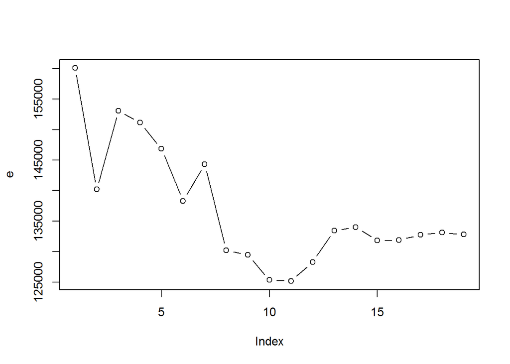

```r
par(mfrow = c(1,1))
plot(e, type = 'b')
```

So the model with 11 predictors has the lowest error rating on the test data set. We now fit the model using the full data set and examine the final coefficients.

```r
best = regsubsets(Salary ~ ., data = data, nvmax = 19)
coef(best, id = 11)
```

```
##  (Intercept)        AtBat         Hits        Walks       CAtBat
##  135.7512195   -2.1277482    6.9236994    5.6202755   -0.1389914
##        CRuns         CRBI       CWalks      LeagueN    DivisionW
##    1.4553310    0.7852528   -0.8228559   43.1116152 -111.1460252
##      PutOuts      Assists
##    0.2894087    0.2688277
```

## Lab 2: Ridge Regression and the Lasso

The `glmnet` function supports both Ridge Regression and Lasso.

```r
library(glmnet)
# ?glmnet
```

- If `alpha = 1` is the lasso penalty is applied, and if `alpha = 0` the ridge penalty is applied.
- By default `glmnet` computes its own lambda sequence based on nlambda and lambda.min.ratio; supplying a value of lambda overrides this.
- Also by default `glmnet()` standardizes the variables so that they are on the same scale, which is critical for Ridge Regression
- `glmnet` also expects an `x` matrix as well as a `y` vector:

```r
# Create the X matrix; exclude the intercept
x = model.matrix(Salary ~ ., data = data)[, -1]

# Collect the Y values
y = data$Salary
```

And finally, we’ll want a test and train set:

```r
set.seed(1)

# Half the data is training data
train = sample(1:nrow(x), nrow(x)/2)

# The other half is test data
test = (-train)

x.train = x[train,]
x.test = x[test,]
y.train = y[train]
y.test = y[test]
```

### Ridge Regression

Create a custom lambda sequence where $\lambda = 10^{10}$ to $\lambda = 10^{-2}$:

```r
lambdaGrid = 10^seq(10, -2, length = 100)
```

Fit the model:

```r
fit = glmnet(x.train, y.train, alpha = 0, lambda = lambdaGrid)
dim(coef(fit))
```

```
## [1]  20 100
```

The result is a coefficient matrix of 100 columns, one for each lambda value, and 20 rows, one for each predictive variable plus the intercept.

```r
# Lambda values for the first model's coefficients
coef(fit)[,1]
```

```
##   (Intercept)         AtBat          Hits         HmRun          Runs
##  5.479846e+02  5.192368e-08  1.790580e-07  8.926999e-07  3.141580e-07
##           RBI         Walks         Years        CAtBat         CHits
##  3.533162e-07  4.732016e-07  1.198689e-06  3.981558e-09  1.501273e-08
##        CHmRun         CRuns          CRBI        CWalks       LeagueN
##  9.980324e-08  3.232510e-08  2.741340e-08  3.625065e-08  3.471972e-06
##     DivisionW       PutOuts       Assists        Errors    NewLeagueN
## -8.090096e-06  2.727067e-08  1.288616e-08  2.804015e-07  3.730442e-06
```

Compute the predictions and error rates:

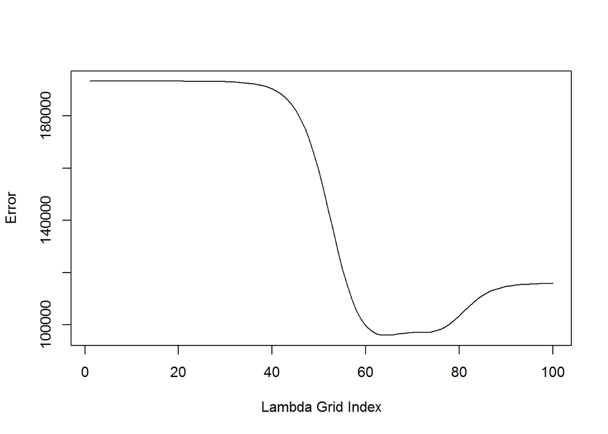

```r
err = rep(0, 100)

for (i in 1:100) {
  p = predict(fit, s = lambdaGrid[i], newx = x.test)
  err[i] = mean((p - y.test)^2)
}

plot(err, type = 'l', ylab = "Error", xlab = "Lambda Grid Index")
```

Print the smallest error rate and corresponding lambda value:

```r
{
print(err[which.min(err)])
print(lambdaGrid[which.min(err)])
}
```

```
## [1] 96010.43
## [1] 231.013
```

Compare our results above to an optimal lambda value determined via cross-validation:

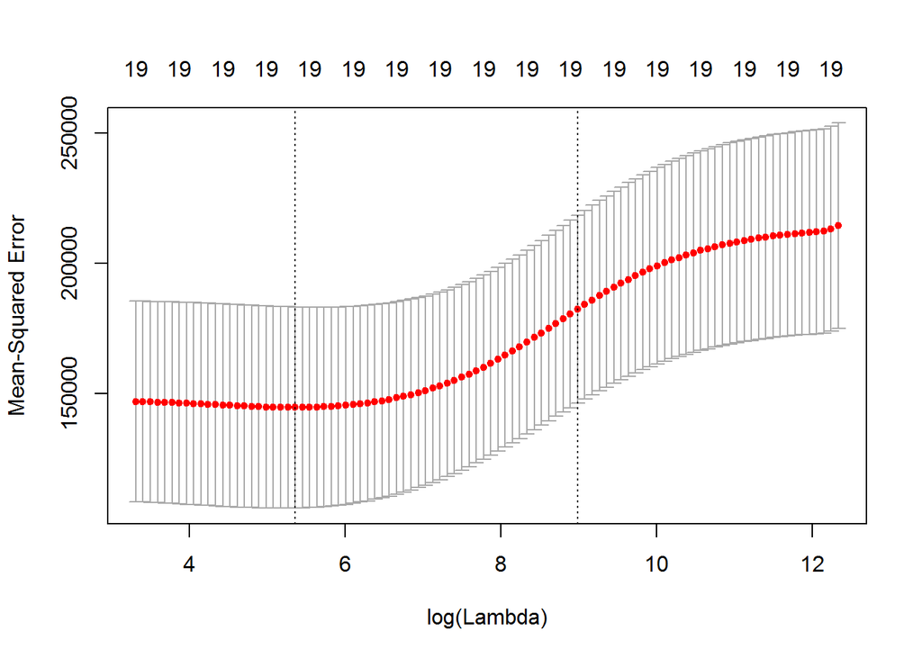

```r
set.seed(1)
cv = cv.glmnet(x.train, y.train, alpha = 0)
plot(cv)
```

```r
cv$lambda.min
```

```
## [1] 211.7416
```

```r
l = cv$lambda.min
p = predict(fit, s = l, newx = x.test)
e = mean((p - y.test)^2)

{
  print(e)
  print(l)
}
```

```
## [1] 96012.47
## [1] 211.7416
```

Both methods give almost exactly the same result.

We can refit the model using all the data and note that none of the coefficients are zero, as Ridge Regression is not a variable selection model:

```r
fit = glmnet(x, y, alpha = 0)
predict(fit, type = "coefficients", s = l)[1:20,]
```

```
##  (Intercept)        AtBat         Hits        HmRun         Runs
##   9.88487157   0.03143991   1.00882875   0.13927624   1.11320781
##          RBI        Walks        Years       CAtBat        CHits
##   0.87318990   1.80410229   0.13074383   0.01113978   0.06489843
##       CHmRun        CRuns         CRBI       CWalks      LeagueN
##   0.45158546   0.12900049   0.13737712   0.02908572  27.18227527
##    DivisionW      PutOuts      Assists       Errors   NewLeagueN
## -91.63411282   0.19149252   0.04254536  -1.81244470   7.21208394
```

### The Lasso

We will now fit and examine the Hitters data utilizing a Lasso model.

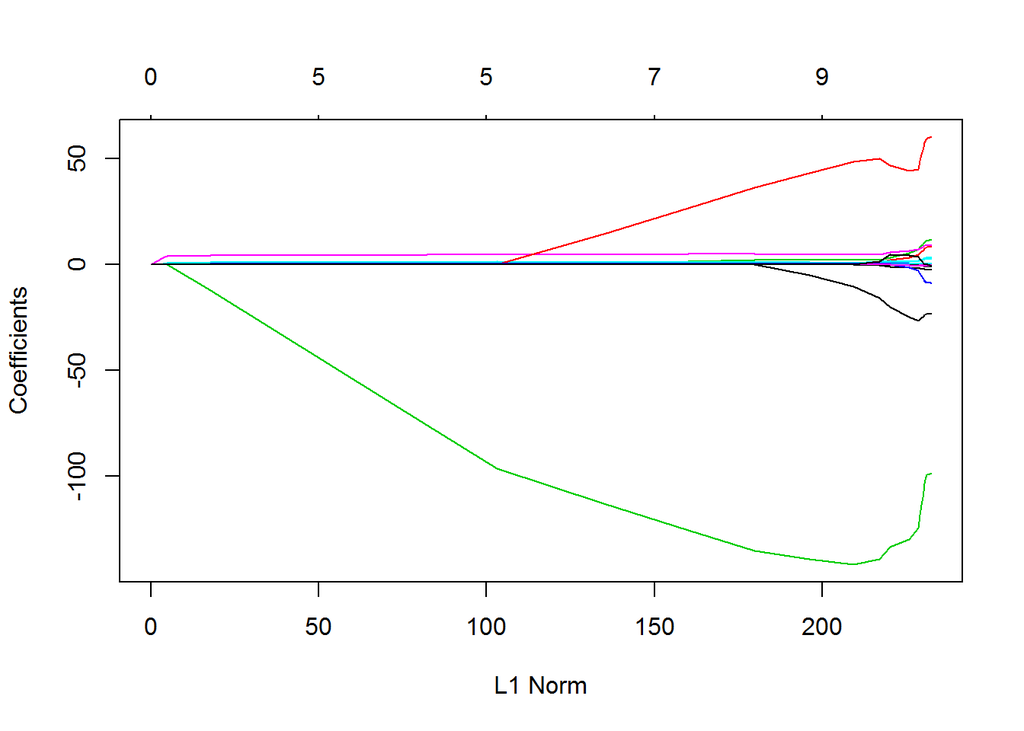

```r
fit = glmnet(x.train, y.train, alpha = 1, lambda = lambdaGrid)
plot(fit)
```

Unlike Ridge Regression we can see that some coefficients have been set to zero for various tuning parameter values. Like Ridge Regression above we can use cross-validation to find the optimal lambda value and compute the error rate:

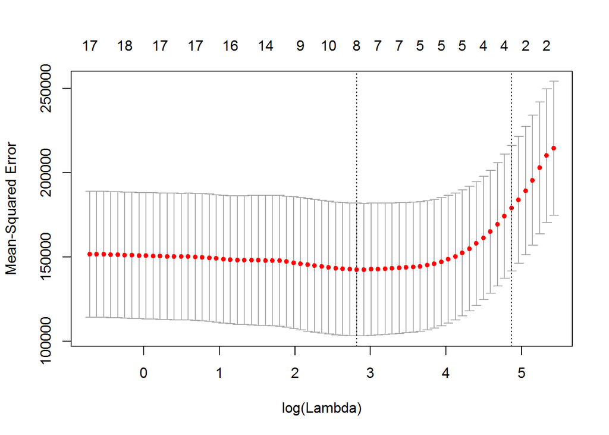

```r
set.seed(1)
cv = cv.glmnet(x.train, y.train, alpha = 1)
plot(cv)
```

```r
l = cv$lambda.min
p = predict(fit, s = l, newx = x.test)
e = mean((p - y.test)^2)

{
  print(e)
  print(l)
}
```

```
## [1] 100743.4
## [1] 16.78016
```

The error rate is very close to that of the Ridge Regression model which was 96012.47. However, if we examine the coefficients we can see that they are sparse (i.e. a number of them have been set to zero) since The Lasso is a variable selection model:

```r
fit = glmnet(x, y, alpha = 1)
predict(fit, type = "coefficients", s = l)[1:20,]
```

```
##  (Intercept)        AtBat         Hits        HmRun         Runs
##   19.5223995    0.0000000    1.8701714    0.0000000    0.0000000
##          RBI        Walks        Years       CAtBat        CHits
##    0.0000000    2.2187934    0.0000000    0.0000000    0.0000000
##       CHmRun        CRuns         CRBI       CWalks      LeagueN
##    0.0000000    0.2072852    0.4127984    0.0000000    1.7591970
##    DivisionW      PutOuts      Assists       Errors   NewLeagueN
## -103.5051402    0.2206884    0.0000000    0.0000000    0.0000000
```

## Lab 3: PCR and PLS Regression

### Principal Component Regression (PCR)

We’ll utilize PCR on the Hitter’s data to predict salary. Note that in the function call below:

- `scale = T` standardizes each predictor prior to generating the principal components
- `validation = 'cv'` causes `pcr()` to compute the ten-fold cross-validation error for each possible value of M, the number of principal components used.

```r
library(pls)
set.seed(2)

fit = pcr(Salary ~ ., data = data, scale = T, validation = 'CV')
summary(fit)
```

```
## Data:    X dimension: 263 19
##  Y dimension: 263 1
## Fit method: svdpc
## Number of components considered: 19
##
## VALIDATION: RMSEP
## Cross-validated using 10 random segments.
##        (Intercept)  1 comps  2 comps  3 comps  4 comps  5 comps  6 comps
## CV             452    348.9    352.2    353.5    352.8    350.1    349.1
## adjCV          452    348.7    351.8    352.9    352.1    349.3    348.0
##        7 comps  8 comps  9 comps  10 comps  11 comps  12 comps  13 comps
## CV       349.6    350.9    352.9     353.8     355.0     356.2     363.5
## adjCV    348.5    349.8    351.6     352.3     353.4     354.5     361.6
##        14 comps  15 comps  16 comps  17 comps  18 comps  19 comps
## CV        355.2     357.4     347.6     350.1     349.2     352.6
## adjCV     352.8     355.2     345.5     347.6     346.7     349.8
##
## TRAINING: % variance explained
##         1 comps  2 comps  3 comps  4 comps  5 comps  6 comps  7 comps
## X         38.31    60.16    70.84    79.03    84.29    88.63    92.26
## Salary    40.63    41.58    42.17    43.22    44.90    46.48    46.69
##         8 comps  9 comps  10 comps  11 comps  12 comps  13 comps  14 comps
## X         94.96    96.28     97.26     97.98     98.65     99.15     99.47
## Salary    46.75    46.86     47.76     47.82     47.85     48.10     50.40
##         15 comps  16 comps  17 comps  18 comps  19 comps
## X          99.75     99.89     99.97     99.99    100.00
## Salary     50.55     53.01     53.85     54.61     54.61
```

The summary indicates that the model using `M = 16` components has the lowest adjusted CV error rate of 345.5. This is only three fewer than simply using all 19 of the model’s variables. Also note that that `pcr()` reports the root mean squared error;in order to obtain the MSE we must square this quantity. So the `M = 16` root mean squared error of 345.5 corresponds to an MSE of 119370.2.

The summary() function also provides the percentage of variance explained in the predictors and in the response using different numbers of components. Briefly, we can think of this as the amount of information about the predictors or the response that is captured using M principal components. For example, setting M = 1 only captures 38.31% of all the variance, or information, in the predictors. In contrast, using M = 6 increases the value to 88.63%. If we were to use all M = p = 19 components, this would increase to 100%.

We can also visually inspect the cross-validation scores using the `validationplot()` validation plot() function. Using `val.type = "MSEP"` argument will cause the cross-validation MSE to be plotted.

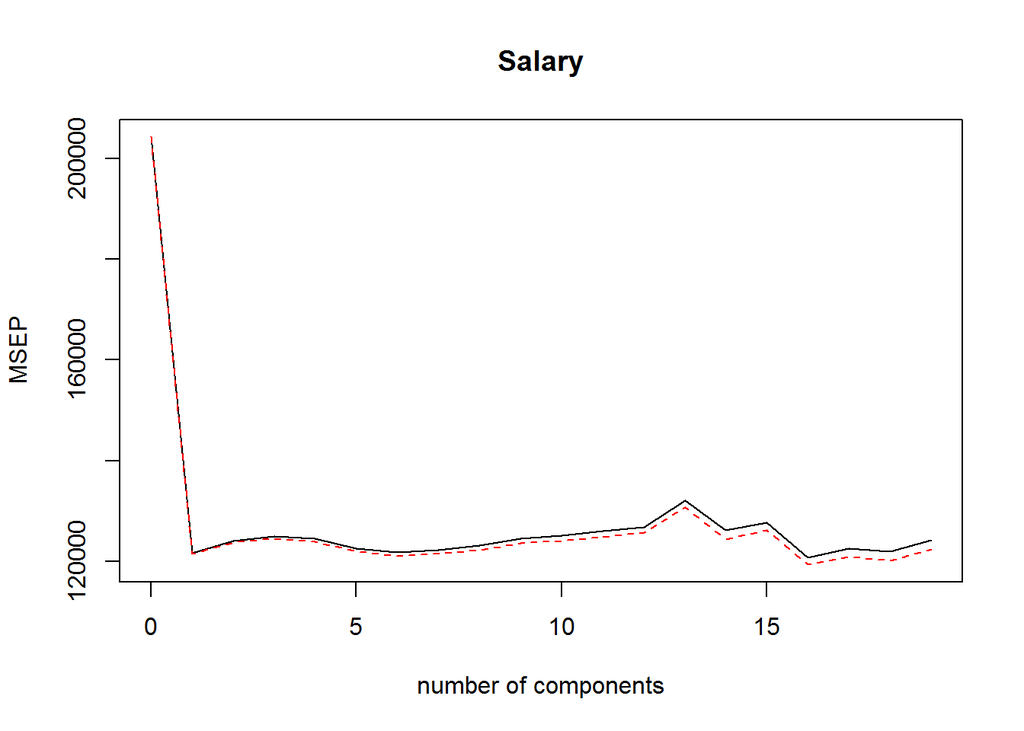

```r
validationplot(fit, val.type = 'MSEP')
```

We can now do the same thing again on the train and test data:

```r
set.seed(1)

fit = pcr(Salary ~ ., data = data, scale = T, validation = 'CV', subset = train)
summary(fit)
```

```
## Data:    X dimension: 131 19
##  Y dimension: 131 1
## Fit method: svdpc
## Number of components considered: 19
##
## VALIDATION: RMSEP
## Cross-validated using 10 random segments.
##        (Intercept)  1 comps  2 comps  3 comps  4 comps  5 comps  6 comps
## CV           464.6    406.1    397.1    399.1    398.6    395.2    386.9
## adjCV        464.6    405.2    396.3    398.1    397.4    394.5    384.5
##        7 comps  8 comps  9 comps  10 comps  11 comps  12 comps  13 comps
## CV       384.8    386.5    394.1     406.1     406.5     412.3     407.7
## adjCV    383.3    384.8    392.0     403.4     403.7     409.3     404.6
##        14 comps  15 comps  16 comps  17 comps  18 comps  19 comps
## CV        406.2     417.8     417.6     413.0     407.0     410.2
## adjCV     402.8     413.9     413.5     408.3     402.4     405.5
##
## TRAINING: % variance explained
##         1 comps  2 comps  3 comps  4 comps  5 comps  6 comps  7 comps
## X         38.89    60.25    70.85    79.06    84.01    88.51    92.61
## Salary    28.44    31.33    32.53    33.69    36.64    40.28    40.41
##         8 comps  9 comps  10 comps  11 comps  12 comps  13 comps  14 comps
## X         95.20    96.78     97.63     98.27     98.89     99.27     99.56
## Salary    41.07    41.25     41.27     41.41     41.44     43.20     44.24
##         15 comps  16 comps  17 comps  18 comps  19 comps
## X          99.78     99.91     99.97    100.00    100.00
## Salary     44.30     45.50     49.66     51.13     51.18
```

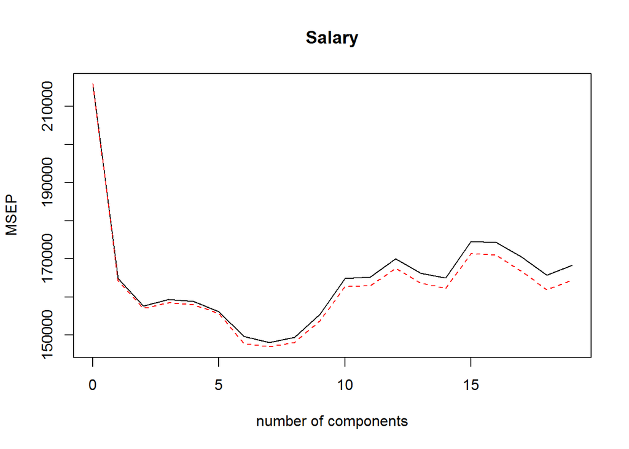

```r
validationplot(fit, val.type = 'MSEP')
```

The lowest cross-validation error occurs when `M = 7` on the training data, and we can utilize the test data to compute the test MSE:

```r
pred = predict(fit, x.test, ncomp = 7)
mean((pred - y.test)^2)
```

```
## [1] 96556.22
```

### Partical Least Squares (PLS)

Mechanically implementing PLS is almost the same as implementing PCR; we simply call the `plsr()` function instead of `pcr()`:

```r
set.seed(1)
fit = plsr(Salary ~ ., data = data, subset = train, scale = T, validation = 'CV')
summary(fit)
```

```
## Data:    X dimension: 131 19
##  Y dimension: 131 1
## Fit method: kernelpls
## Number of components considered: 19
##
## VALIDATION: RMSEP
## Cross-validated using 10 random segments.
##        (Intercept)  1 comps  2 comps  3 comps  4 comps  5 comps  6 comps
## CV           464.6    394.2    391.5    393.1    395.0    415.0    424.0
## adjCV        464.6    393.4    390.2    391.1    392.9    411.5    418.8
##        7 comps  8 comps  9 comps  10 comps  11 comps  12 comps  13 comps
## CV       424.5    415.8    404.6     407.1     412.0     414.4     410.3
## adjCV    418.9    411.4    400.7     402.2     407.2     409.3     405.6
##        14 comps  15 comps  16 comps  17 comps  18 comps  19 comps
## CV        406.2     408.6     410.5     408.8     407.8     410.2
## adjCV     401.8     403.9     405.6     404.1     403.2     405.5
##
## TRAINING: % variance explained
##         1 comps  2 comps  3 comps  4 comps  5 comps  6 comps  7 comps
## X         38.12    53.46    66.05    74.49    79.33    84.56    87.09
## Salary    33.58    38.96    41.57    42.43    44.04    45.59    47.05
##         8 comps  9 comps  10 comps  11 comps  12 comps  13 comps  14 comps
## X         90.74    92.55     93.94     97.23     97.88     98.35     98.85
## Salary    47.53    48.42     49.68     50.04     50.54     50.78     50.92
##         15 comps  16 comps  17 comps  18 comps  19 comps
## X          99.11     99.43     99.78     99.99    100.00
## Salary     51.04     51.11     51.15     51.16     51.18
```

The lowest cross-validation error occurs when only `M = 2` partial least squares directions are used. We now evaluate the corresponding test set MSE.

```r
pred = predict(fit, x.test, ncomp = 2)
mean((pred - y.test)^2)
```

```
## [1] 101417.5
```

The test MSE is comparable to, but slightly higher than, the test MSE obtained using ridge regression, the lasso, and PCR. Finally, we perform PLS using the full data set, using `M = 2`, the number of components identified by cross-validation.

```r
fit = plsr(Salary ~ ., data = data, scale = T, ncomp = 2)
summary(fit)
```

```
## Data:    X dimension: 263 19
##  Y dimension: 263 1
## Fit method: kernelpls
## Number of components considered: 2
## TRAINING: % variance explained
##         1 comps  2 comps
## X         38.08    51.03
## Salary    43.05    46.40
```

Notice that the percentage of variance in Salary that the two-component PLS fit explains, 46.40%, is almost as much as that explained using the final seven-component model PCR fit, 46.69%. This is because PCR only attempts to maximize the amount of variance explained in the predictors, while PLS searches for directions that explain variance in both the predictors and the response.